## **AZUL4**

Hoje, sexta-feira, 2025-08-22, a ação AZUL4 fechou o dia em alta, com um ganho de 1,75% em relação ao dia anterior. Isso significa que a cotação do ativo subiu de R$ 0,57 para R$ 0,58, uma variação significativa e positiva.No entanto, se olharmos para o desempenho mais amplo da ação, vemos que o AZUL4 não tem sido muito popular nos últimos meses. Com uma perda de 28,4% no mês, 38,9% no trimestre e 82,4% no ano, é claro que a tendência recente foi negativa.Mas, como um outlier, o dia de hoje demonstrou um ponto crucial de negociação às 13:52:00s, quando uma grande quantidade do ativo foi negociada, representando 27,19% do total negociado no dia. Essa negociação impactou diretamente na cotação do ativo, que aumentou em 3,039% logo após.Em resumo, o AZUL4 apresentou um desempenho positivo hoje, mas não é uma tendência sustentável. É preciso observar mais cuidadosamente a evolução da ação nos próximos dias para entender melhor se essa alta é apenas um movimento isolado ou parte de uma mudança mais ampla na tendência do ativo. Veja a seguir o gráfico do intraday com o destaque do outlier: as setas amarelas destacam o momento e o volume negociado no ponto de outlier. A linha violeta demonstra a tendência do preço antes e depois do destaque.

[figure not shown]

A seguir, desempenho do ativo ao longo do tempo:

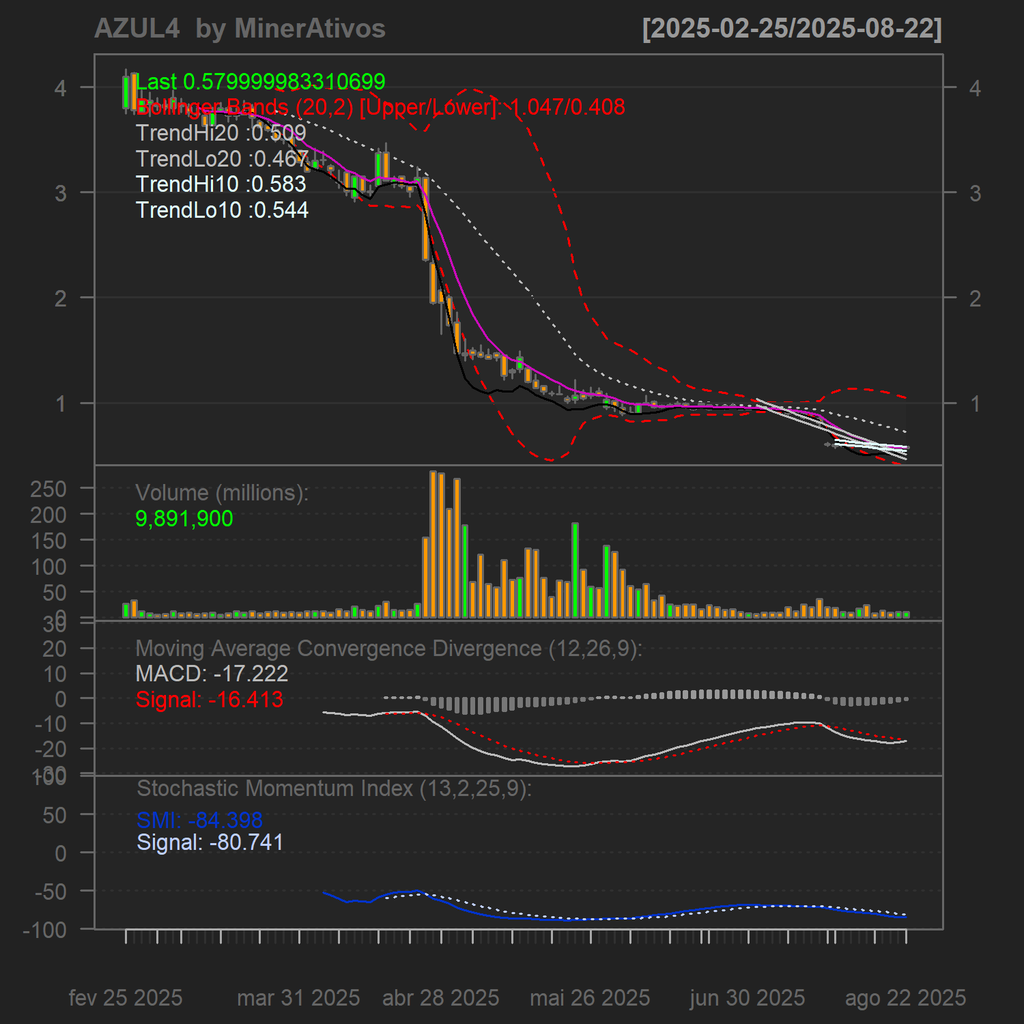

[figure not shown]